# Gov 97 Final Analysis

Garrett Rolph

```
##  [1] 51.72414 50.00000 63.63636 42.10526 52.50000 53.57143 68.75000 51.08696
##  [9] 51.16279 57.14286 41.66667 55.00000 58.33333 51.56250 61.53846 65.00000
## [17] 52.94118 61.36364 59.78261 44.44444 57.89474 55.26316 53.84615 63.88889
## [25] 52.04082 85.57692 59.09091 54.54545 55.46875 56.25000
```

```
##  [1] "AR" "TN" "OH" "NJ" "TX" "CT" "KS" "DC" "NM" "NY" "WA" "LA" "AZ" "FL" "MA"
## [16] "IL" "GA" "WI" "NC" "MS" "PA" "CA" "MD" "SC" "IN" "MN" "CO" "ID" "NH" "OK"
## [31] "VA" "MI" "NV" "WV" "KY" "ME" "HI" "IA" "OR" "AL" "VT" "ND" "NE" "WY" "UT"
## [46] "MO" "MT" "AK" "DE" "RI" "SD"
```

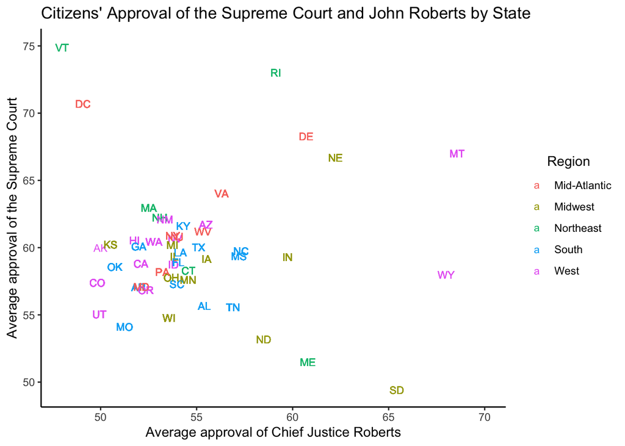

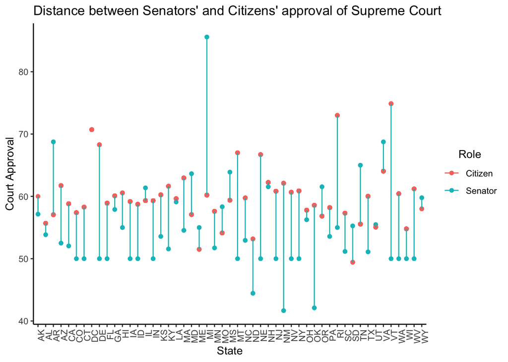

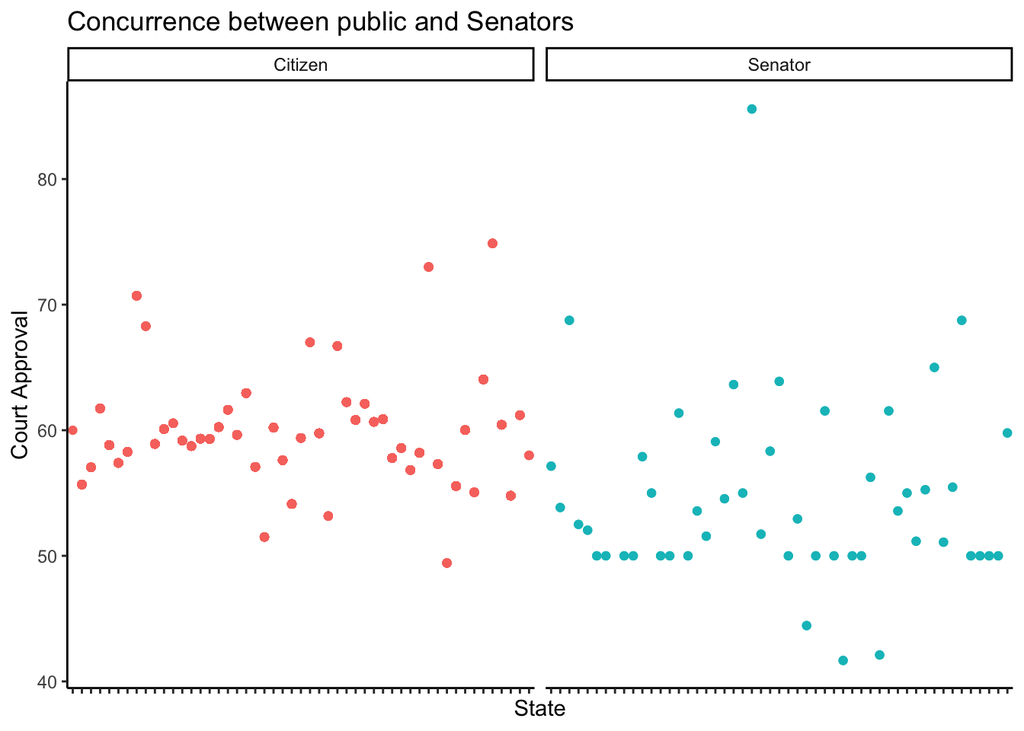

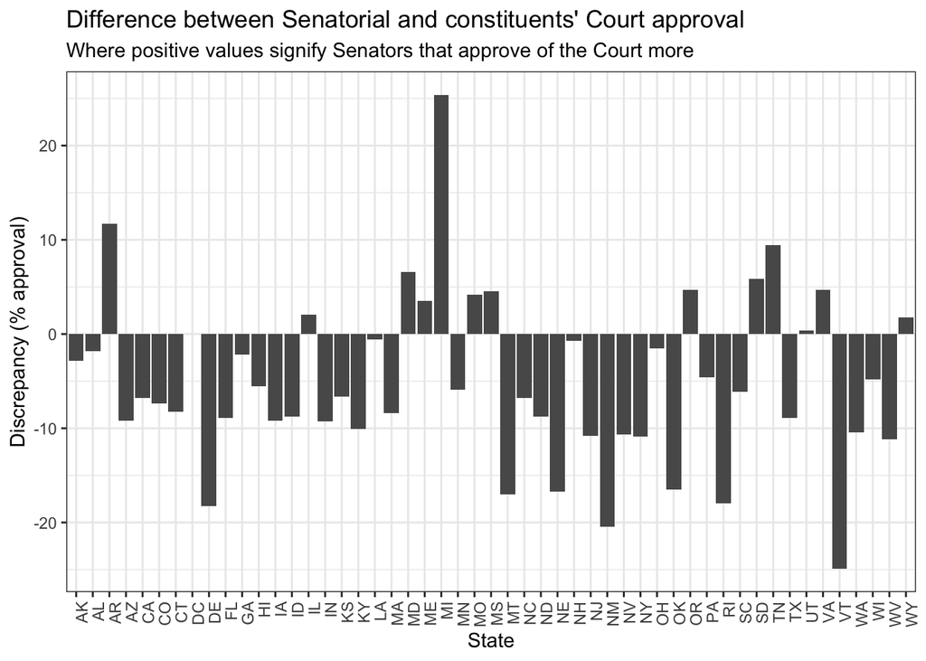

List of potential words for negative Senator tweets: undermine(d), at odds, disappointed, ignored, blocks, partisan, power grab, myth, glad, politicization, mandate(d), troubling, misguided, support of overturning, erroneous, justice delayed, deserve greater transparency, loss, love won, gut(ted)(ing), outrageous oppression, upholding nationwide subsidies, rejects Oklahoma, unravel, corrosive power, fix this, got it wrong, got #HobbyLobby wrong, I am concerned, was wrong, struck down a key section, shut the door, disastrous, overturn Citizens United, The real loser in today, damaging law, ruling does not repudiate, blame,

Neutral list? Historic, upholds, (goes two ways: support(ed)(ing))

List of potential words for positive Senator tweets: great, two thumbs up, recognizes, good news, thank you, welcome news, P(p)leased, integrity, follow(s)(ing) the law, affirm(ed), equality, ensure, proud, agree, major victory, fight against, against, equity, respect, abide by, applaud the, forward to override, vote to override, religious liberty, welcomed, Applaud, unanimously that segregation, deals major blow, a good step in, support this decision, declined to hear, rejected the NC, I support the Supreme Court, blocks implementation of, Marriage Act unconstitutional, cheering, right conclusion, confirmed today it, Supreme Court Reins in, Supreme Court Rebukes, Good to see, decision to block @EPA, unanimously agreed, in Brown, Praises, Commends, affirmed again, Applauds, access to abortion is a woman, unanimously rebuked, regulations on hold, outlawed segregation, #ACAWorks, halts EPA, religious freedom should be protected,